# Module 4, Lesson 1: Sharing your work

In this lesson, we learned about two functions for exporting your work from R: `ggsave` from the `ggplot2` package for exporting images and `write_csv` from the `readr` package for exporting tables.

## Exporting images using `ggsave`

Here is the plot of infant height against weight, faceted by the month of the measurement.

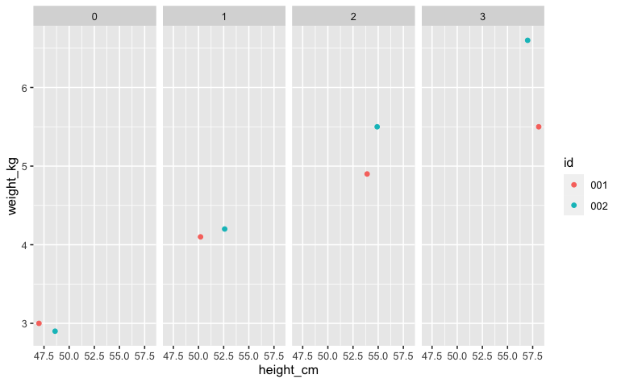

The astute observers among you will notice that Phil (accidentally) swapped his x and y aesthetics in the videos: in the video lecture, he mapped `weight_kg` to the x aesthetic and `height_cm` to the y aesthetic, whereas in the guided practice he mapped `height_cm` to the x aesthetic and `weight_kg` to the y aesthetic. For purposes of illustration, whichever you do is fine, but we will use here the version from the guided practice.

The simplest use case of `ggsave` is as follows:

```r
ggsave("weight_vs_height.png")
```

Inevitably, you will need to recreate an image, perhaps days or weeks after you initially created it. At that point, it is hopeless to try to resize the panel by trial and error to match the dimensions of the previous version. For this reason, it is recommended that you explicitly provide the dimensions in the call to `ggsave`:

```r
ggsave(filename = "weight_vs_height.png", width = 8, height = 4)
```

Now we have saved the plot as a .png image file that is 8in wide and 4in tall (note that the message about the dimensions is no longer printed to the screen, being redundant information). Since the first argument to `ggsave` is `filename`, you can rely upon the concept of positional matching (see Module 3, Lesson 3) to avoid writing `filename =`:

```r
ggsave("weight_vs_height.png", width = 8, height = 4)
```

The `width` and `height` arguments are not the second and third arguments, so you cannot use positional matching to avoiding writing their names explicitly. You also might be interested in changing the default units of measurement from inches to something more intuitive, like cm. To do so, use the `units` argument:

```r
ggsave("weight_vs_height.png", width = 18, height = 8, units = "cm")
```

The values of `width` and `height` should represent whatever units of measurement you have specified, meaning that the code above would save the plot as an image file 18cm wide and 8cm tall.

Another useful piece of information is that the `filename` name argument can be a *path* and not just a file name. Look at *but don’t yet run* the following code:

```r
ggsave("module4/weight_vs_height.png", width = 18, height = 8, units = "cm")
```

Before the file name is `module4/`, which is a ‘relative path’ pointing to a folder called ‘module4’. The word ‘relative’ means that R will look for this folder relative to your working directory, which, as long as you are working inside the the ‘Lessons’ R project, will be the folder called ‘Lessons’. So, in order for this code to run without an error, you should first create on your computer a new folder called ‘module4’ *inside of the ‘Lessons’ folder*. After doing so, run the code above. If you run the code without having created the ‘module4’ folder, you will encounter an error from R.

It is not required that you specify a relative path; however, doing so will save you some work if you would otherwise have to move the image file to a different location after creating it.

The last thing to observe about `ggsave` is that the second argument is named `plot`, and in none of the examples above did we even bother to specify a value for `plot`. How is this possible? This is possible because the default value for `plot` is to use the last plot that you created in R. So, if you were to run the following code on your computer, the resulting image files would contain distinct plots even though we did not specify the `plot` argument in either call to `ggsave`:

```r
ggplot(growth_data,
       aes(x = height_cm, y = weight_kg, color = id)) +
  geom_point() +
  facet_grid(cols = vars(months))
ggsave("module4/weight_vs_height.png", width = 18, height = 8, units = "cm")

ggplot(growth_data,
       aes(x = height_cm)) +
  geom_histogram(binwidth = 5)
ggsave("module4/height_distribution.png", width = 18, height = 8, units = "cm")
```

In contrast, were you to run the following code, it would save the *same* plot (namely, the histogram from the second block of code) twice – one in a file named ‘weight_vs_height.png’ and another in ‘height_distribution.png’:

```r
# Don't run this code!
ggplot(growth_data,
       aes(x = height_cm, y = weight_kg, color = id)) +
  geom_point() +
  facet_grid(cols = vars(months))

ggplot(growth_data,
       aes(x = height_cm)) +
  geom_histogram(binwidth = 5)

ggsave("module4/weight_vs_height.png", width = 18, height = 8, units = "cm")
ggsave("module4/height_distribution.png", width = 18, height = 8, units = "cm")
```

This is presumably not what you would intend.

## Exporting tables using `write_csv`

You can write `data.frame`s (of which `tibble`s are special cases) to your computer’s hard drive using the `write_csv` function. Typically, the sort of `data.frame` that you would want to export would be tables of statistics or results. However, we will demonstrate use of `write_csv` on the `growth_data` object in the `healthds` packages.

### Remark: `write_csv` versus `write.csv`

The `write_csv` function is part of the `tidyverse` and therefore the function that we will be using here. There is a similar-looking function called `write.csv` which comes pre-loaded as part of the base installation of R. Which functions you end up using is not critical – `write_csv` will be faster when you are writing large `data.frame`s, and there are some other differences in other default behavior.

To use `write_csv`, we need to specify two arguments at a minimum: the name of the `data.frame` (the `x` argument) to write and the desired filename (the `file` argument). In contrast to `ggsave`, there is no default behavior to write the “last” `data.frame` used and so you need to explicitly indicate what `data.frame` you want to save to the computer via `x`. The `file` argument in `write_csv` is analogous to the `filename` argument in `ggsave`, but note that it comes *second* in `write_csv` and not first.

```r
write_csv(x = growth_data, file = "module4/growth_data.csv")
```

Like `ggsave`, this code will save the `growth_data` object to the folder named ‘module4’ that is within your current working directory, which is the ‘Lessons’ folder in our case. We *don’t* put quotes around `growth_data` because it is an R object name; we *do* put quotes around `module4/growth_data.csv` because it is not an R object but rather a path.

You can use positional matching here, too, meaning that the following code has the same behavior:

```r
write_csv(growth_data, "module4/growth_data.csv")
```

There will now be a new file with a ‘.csv’ suffix in the module4 folder. You can distribute it just as you would any other file, and if you double-click it, it will open in your spreadsheet program.